# Field Decoder — Encoder Heads Greenland 2026

Single-message decode, diagnostics & plots

Author

Thom Laepple

Published

July 7, 2026

## Parameters

Edit this block, then re-render (`Ctrl+Shift+K`).

```r
# Identification is purely by IMEI — the "IMEI: <id>" line in the Cloudloop mail,
# which is also the .bin filename prefix (e.g. 300434065508020-2.bin). For a .bin
# attachment the IMEI is auto-detected from the filename; the head's n_nodes /
# fields / type / spacing then come from head_config[[IMEI]].
IMEI <- ""   # "" = auto-detect from BIN_FILE; set manually for a hex payload

# Path(s) to the .bin attachment(s) from the Cloudloop email ------------------
# One file → single decode as before. A VECTOR of files → a time series: the
# newest message drives the single-message sections (summary, table, profile),
# and ALL files feed the extra "Zeitlicher Verlauf" plot. All files must be the
# same head (same IMEI). Use Sys.glob() to pick up every file for one device.
# -2 excluded: head was not yet erected at that time, so its profile is invalid.
BIN_FILE <- setdiff(Sys.glob("../testdata/300434065508020-*.bin"),
                    "../testdata/300434065508020-2.bin")

# OR paste hex payload(s) from the email (set IMEI above, leave BIN_FILE = "")--
# If the head sends two messages per measurement, paste both.
MSG1 <- ""
MSG2 <- ""
```

```r
head_config <- list(
  # One entry per deployed head, KEYED BY IMEI. `label` is just a human name;
  # n_nodes / fields / type / spacing_cm are authoritative for decoding & plots.
  # `calibration` = path to a per-sensor lab calibration table
  # (position,node,ntc,a,b,c,d); NA → decode with the universal mean lab-S4 curve.
  "301434062008130" = list(label = "Kette (chain)", n_nodes = 20L,
                 fields = c("ntc1", "ntc2", "gnd", "pressure"),
                 type = "standard", spacing_cm = NA_integer_,
                 calibration = NA_character_),
  "300434065508020" = list(label = "Snowmelt NEWGRIP", n_nodes = 24L,
                 fields = c("ntc1", "ntc2", "testSB"),
                 type = "snowmelt", spacing_cm = 4L,
                 calibration = "../meta/GRIP_calibration_assignment.csv")
  # Add further heads here, one per IMEI.
)

# --- Identify head by IMEI ---------------------------------------------------
# For a .bin attachment the IMEI is the filename prefix; for a hex payload set
# IMEI manually above. The IMEI is the sole selector into head_config.
# BIN_FILE may be a vector (time series); keep only the non-empty paths.
bin_files <- BIN_FILE[nzchar(BIN_FILE)]
use_bin   <- length(bin_files) > 0L

imei <- if (IMEI != "") {
  IMEI
} else if (use_bin) {
  imeis <- unique(sub("-.*$", "", basename(bin_files)))
  if (length(imeis) > 1L)
    stop("BIN_FILE mixes IMEIs (", paste(imeis, collapse = ", "),
         ") — a time series must be one head.")
  imeis
} else {
  stop("Set IMEI (hex payload) or BIN_FILE (.bin attachment).")
}
cfg  <- head_config[[imei]]
if (is.null(cfg))
  stop(sprintf("IMEI '%s' is not in head_config — add an entry for this device.", imei))

n_nodes <- cfg$n_nodes
fields  <- cfg$fields

# --- Per-sensor lab calibration (optional, keyed by head) --------------------
# If the head has a `calibration` table, decode counts→°C with the per-sensor
# 4-param Steinhart–Hart fit (NTC_s4) instead of the universal Beta curve.
# `position` in that table is the decode order (1 = first node in the stream),
# so it maps 1:1 onto the node index used below. Any sensor whose fit is missing
# or numerically broken falls back to the universal mean lab-S4 curve
# (NTC_mean; handled in calibrate_channel).
ntc_channel <- c(ntc1 = 1L, ntc2 = 2L, testSB = 3L)   # field name → NTC number
lab_cal <- NULL
cal_path <- cfg$calibration
if (!is.null(cal_path) && !is.na(cal_path)) {
  if (file.exists(cal_path)) {
    ca <- read.csv(cal_path)
    lab_cal <- setNames(lapply(names(ntc_channel), function(fld) {
      k <- ntc_channel[[fld]]
      lapply(seq_len(n_nodes), function(p) {
        r  <- ca[ca$position == p & ca$ntc == k, c("a", "b", "c", "d")]
        co <- if (nrow(r) == 1L) as.numeric(r) else NULL
        if (!is.null(co) && all(is.finite(co))) co else NULL
      })
    }), names(ntc_channel))
  } else {
    warning(sprintf("Calibration table '%s' not found — decoding with Beta.", cal_path))
  }
}
n_lab_sensors <- if (is.null(lab_cal)) 0L else
  sum(sapply(names(lab_cal), function(ch)
    if (ch %in% fields) sum(!vapply(lab_cal[[ch]], is.null, logical(1))) else 0L))
n_ntc_sensors <- n_nodes * sum(fields %in% names(ntc_channel))
cal_method <- if (is.null(lab_cal)) "Mittlere Lab-S4-Kurve (universeller Fallback)" else
  sprintf("Lab-S4 pro Sensor (%d/%d) mit Mean-S4-Fallback", n_lab_sensors, n_ntc_sensors)

# Per-field value width in BYTES (binary) — gnd is int16, the rest int24/uint24.
bin_field_bytes <- function(f) {
  if (f %in% c("ntc1", "ntc2", "testSB", "pressure")) return(3L)
  if (f == "gnd") return(2L)
  stop("Unknown field: ", f)
}

# Expected binary file size for N nodes with these fields, in two firmware
# variants: each field is either preceded by a 0x7C separator byte ("sep") or
# the fields are concatenated directly ("nosep"). Layout in both cases:
#   4 B timestamp + adc(3) + N × node + battery(2), separators add +1 B/field.
bin_expected_len <- function(n_nodes, fields) {
  w <- sapply(fields, bin_field_bytes)
  list(sep   = 4L + (1L + 3L) + n_nodes * sum(1L + w) + (1L + 2L),
       nosep = 4L +        3L  + n_nodes * sum(w)       +        2L)
}

if (!use_bin) {
  n_hex_node   <- sum(ifelse(fields %in% c("ntc1", "ntc2", "testSB", "pressure"), 6L, 4L))
  expected_hex <- 8L + 6L + n_nodes * n_hex_node + 4L
} else {
  exp_len <- bin_expected_len(n_nodes, fields)
  for (bf in bin_files) {
    n_file  <- file.info(bf)$size
    # A defective sensor can emit an out-of-range value needing >3 B, so a sep
    # file may be a few bytes LARGER than exp_len$sep — tolerate small surplus.
    surplus <- n_file - exp_len$sep
    ok <- n_file == exp_len$nosep || (surplus >= 0L && surplus <= n_nodes)
    if (!ok)
      warning(sprintf("%s is %d B but IMEI %s (%s) implies %d B (with) or %d B (without separators) for %d nodes — check head_config",
                      basename(bf), n_file, imei, paste(fields, collapse = "/"),
                      exp_len$sep, exp_len$nosep, n_nodes))
    else if (surplus > 0L)
      message(sprintf("%s is %d B (+%d over %d) — likely a defective sensor sending an oversized value; affected field(s) will read NA.",
                      basename(bf), n_file, surplus, exp_len$sep))
  }
}
```

## Decode functions

```r
hex_to_uint <- function(h) {
  if (is.na(h) || nchar(h) == 0L) return(NA_real_)
  chars  <- strsplit(toupper(h), "", fixed = TRUE)[[1]]
  nibble <- match(chars, c(as.character(0:9), LETTERS[1:6])) - 1L
  if (any(is.na(nibble))) return(NA_real_)
  v <- 0; for (d in nibble) v <- v * 16 + d; v
}

hex_to_int <- function(h, bits) {
  v <- hex_to_uint(h)
  if (is.na(v)) return(NA_integer_)
  s <- 2^(bits - 1L)
  if (v >= s) v <- v - 2^bits
  as.integer(v)
}

field_spec <- function(name) {
  if (name == "time_unix")  return(list(n = 8L, fn = hex_to_uint))
  if (name == "adc_temp")   return(list(n = 6L, fn = function(h) hex_to_int(h, 24L)))
  if (name == "battery_mv") return(list(n = 4L, fn = hex_to_uint))
  if (grepl("\\.(ntc1|ntc2|testSB)$", name))
    return(list(n = 6L, fn = function(h) hex_to_int(h, 24L)))
  if (grepl("\\.pressure$", name))
    return(list(n = 6L, fn = hex_to_uint))
  if (grepl("\\.gnd$", name))
    return(list(n = 4L, fn = function(h) hex_to_int(h, 16L)))
  stop("Unknown field: ", name)
}

build_schema <- function(n_nodes, fields) {
  node_fields <- paste(
    sapply(seq_len(n_nodes), function(i)
      paste(paste0("n", i, ".", fields), collapse = " ")),
    collapse = " "
  )
  paste("time_unix adc_temp", node_fields, "battery_mv")
}

decode_hex <- function(schema, hex) {
  fnames <- strsplit(trimws(schema), "\\s+")[[1]]
  pos    <- 1L
  out    <- setNames(vector("list", length(fnames)), fnames)
  for (i in seq_along(fnames)) {
    sp      <- field_spec(fnames[i])
    block   <- substr(hex, pos, pos + sp$n - 1L)
    out[[i]] <- if (nchar(block) == sp$n) sp$fn(block) else NA
    pos <- pos + sp$n
  }
  out
}

adc2temp       <- function(c) 6.101e-5 * c - 256.6

# counts → NTC resistance (Ω). Shared by both calibrations below.
NTCcounts2R <- function(c) {
  H <- (-c * 1e6) / (c - 33554432)
  (H * 499000) / (499000 - H)
}
# Per-sensor lab calibration: 4-parameter Steinhart–Hart on ln(R).
NTC_s4 <- function(c, co) {
  lr <- log(NTCcounts2R(c))
  1 / (co[1] + co[2] * lr + co[3] * lr^2 + co[4] * lr^3) - 273.15
}
# Universal FALLBACK calibration: the MEAN lab-S4 coefficient set, i.e. the
# average of the 62 healthy GRIP sensors (a,b,c,d averaged after dropping the
# 10 a_suspect fits from GRIP_calibration_assignment.csv). Because 1/T is LINEAR
# in (a,b,c,d), the mean coefficients reproduce the mean 1/T curve EXACTLY; that
# curve represents every healthy sensor to ±0.03–0.05 °C (SD) over −40…0 °C.
# Used where a head has no per-sensor lab table (head_config `calibration` = NA)
# or where an individual lab fit is missing/numerically broken. Derivation:
# Greenland2026/derive_mean_calibration.R.
NTC_MEAN_COEF <- c(8.4229499262e-04, 2.7615486685e-04,
                   -3.1654916185e-06, 3.0727486494e-07)
NTC_mean <- function(c) NTC_s4(c, NTC_MEAN_COEF)
# Legacy universal Beta curve (β = 3380, R25 = 10 kΩ). NO LONGER the decoding
# fallback (it reads systematically too warm: −0.7 °C at 0 °C growing to −3.2 °C
# at −40 °C vs. the mean lab curve). Kept only for the lab-vs-Beta diagnostic.
NTC_beta <- function(c) {
  r <- NTCcounts2R(c)
  1 / ((1 / 3380) * log(r / 10000) + 1 / 298.15) - 273.15
}
# Back-compat alias so any external caller still resolves → mean lab curve.
NTCcounts2temp <- NTC_mean

pressure2hPa   <- function(p) p / 1000
unix2utc       <- function(t) as.POSIXct(t, origin = "1970-01-01", tz = "UTC")

# Binary snowchain/snowmelt decoder — field-driven by `fields`:
#   4-byte BE timestamp + adc(int24) + N × node + battery(uint16)
# Each node holds one value per entry of `fields`, in order:
#   ntc1/ntc2/testSB → 3-byte signed int24, gnd → 2-byte signed int16,
#   pressure → 3-byte unsigned uint24.
# Two firmware variants:
#   sep   — every value is preceded by a 0x7C separator byte. Fields are read
#           BETWEEN separators (variable length): a defective sensor can emit an
#           out-of-range value that needs >3 bytes; such wrong-width fields are
#           returned as NA so the rest stays aligned.
#   nosep — values concatenated directly, fixed width (no recovery possible).
# Detected from byte 5 (== 0x7C ⇒ sep), since a sentinel/defective field shifts
# the file size. n_nodes comes from head_config (authoritative).
read_snowchain_bin <- function(path, fields, n_nodes) {
  raw  <- readBin(path, what = "raw", n = file.info(path)$size)
  n    <- length(raw)
  ints <- as.integer(raw)

  has_sep <- ints[5] == 0x7CL

  be_uint <- function(b) sum(as.integer(b) * 256^rev(seq_along(b) - 1L))
  be_sint <- function(b) {
    v <- be_uint(b); bits <- 8L * length(b)
    if (v >= 2^(bits - 1L)) v - 2^bits else v
  }

  nf     <- length(fields)
  widths <- c(3L, rep(sapply(fields, bin_field_bytes), n_nodes), 2L)  # adc, nodes…, battery
  signed <- c(TRUE, rep(fields != "pressure", n_nodes), FALSE)
  n_val  <- length(widths)

  # Decode one field's bytes; wrong length (defective sensor / sentinel) → NA.
  decode_one <- function(b, w, sgn) {
    if (length(b) != w) return(NA_real_)
    if (sgn) be_sint(b) else be_uint(b)
  }

  time_unix   <- be_uint(raw[1:4])
  bat_lo <- NA_integer_; bat_hi <- NA_integer_; bat_partial <- FALSE

  if (has_sep) {
    sep_pos <- which(ints == 0x7CL); sep_pos <- sep_pos[sep_pos >= 5L]
    if (length(sep_pos) != n_val)
      warning(sprintf("Found %d separators, expected %d (adc + %d×%d fields + battery) — alignment may be off (0x7C in data?)",
                      length(sep_pos), n_val, n_nodes, nf))
    fstart <- sep_pos + 1L
    fend   <- c(sep_pos[-1] - 1L, n)
    vals   <- lapply(seq_len(min(length(sep_pos), n_val)), function(i)
      decode_one(raw[fstart[i]:fend[i]], widths[i], signed[i]))
  } else {
    # nosep is fixed-width, BUT a defective sensor emits the overflow sentinel
    # 0x01000000, which needs 4 bytes in a 3-byte field. Detect it by signature
    # and consume the extra byte to re-align the rest of the stream.
    pos  <- 5L
    vals <- vector("list", n_val)
    for (i in seq_len(n_val)) {
      w <- widths[i]
      if (w == 3L && pos + 3L <= n && all(ints[pos:(pos + 3L)] == c(1L, 0L, 0L, 0L))) {
        vals[[i]] <- NA_real_                       # defective sensor → NA, skip 4 B
        pos <- pos + 4L
      } else if (i == n_val && pos + w - 1L > n && pos <= n) {
        # battery low byte(s) lost to a sentinel shift: only the high byte(s)
        # survived → reconstruct a 256-mV range from what is left.
        navail <- n - pos + 1L
        hb     <- be_uint(raw[pos:n]) * 256L^(w - navail)
        bat_lo <- as.integer(hb)
        bat_hi <- as.integer(hb + 256L^(w - navail) - 1L)
        bat_partial <- TRUE
        vals[[i]] <- hb
        pos <- n + 1L
      } else {
        vals[[i]] <- decode_one(raw[pos:(pos + w - 1L)], w, signed[i])
        pos <- pos + w
      }
    }
  }

  node_vals  <- vals[2:(1L + n_nodes * nf)]
  nodes_raw  <- lapply(seq_len(n_nodes), function(i)
    setNames(node_vals[((i - 1L) * nf + 1L):(i * nf)], fields))
  battery_mv <- as.integer(vals[[n_val]])
  if (!bat_partial) { bat_lo <- battery_mv; bat_hi <- battery_mv }

  list(time_unix = time_unix, adc_temp = vals[[1]], nodes = nodes_raw,
       battery_mv = battery_mv, battery_lo = bat_lo, battery_hi = bat_hi,
       battery_partial = bat_partial, n_nodes = n_nodes, has_sep = has_sep)
}
```

## Decode

```r
library(dplyr)
library(tidyr)
library(ggplot2)
library(patchwork)

# counts → °C for one NTC channel across all nodes: the per-sensor lab fit where
# available (and numerically sane), else the universal mean lab-S4 fallback
# (NTC_mean). `counts` is in node
# (= decode = calibration `position`) order, so index p selects the right sensor.
calibrate_channel <- function(counts, field) {
  out <- NTC_mean(counts)                         # default: mean lab curve everywhere
  if (!is.null(lab_cal) && field %in% names(ntc_channel)) {
    for (p in seq_along(counts)) {
      co <- lab_cal[[field]][[p]]
      if (is.null(co) || is.na(counts[p])) next
      t <- NTC_s4(counts[p], co)
      if (is.finite(t) && t > -80 && t < 60) out[p] <- t   # sane lab fit → use it
    }
  }
  out
}

# Turn one decoded message into a tidy per-node data.frame. Both the raw counts
# (before calibration, *_counts) and the calibrated value are kept. The *_C value
# uses the per-sensor lab calibration when the head has one (see cal_method).
bin_to_nodes <- function(b) {
  df <- data.frame(node = seq_len(n_nodes))
  for (f in fields) {
    vals <- sapply(b$nodes, function(nd) nd[[f]])
    if (f %in% c("ntc1", "ntc2", "testSB")) {
      df[[paste0(f, "_counts")]] <- vals
      df[[paste0(f, "_C")]]      <- calibrate_channel(vals, f)
    } else if (f == "pressure") {
      df$pressure_counts <- vals
      df$pressure_hPa    <- pressure2hPa(vals)
    } else {                       # gnd → raw counts (already uncalibrated)
      df[[f]] <- vals
    }
  }
  df
}

if (use_bin) {
  # ---- Binary snowchain path ------------------------------------------------
  # Decode every file, then order oldest → newest by timestamp. The NEWEST
  # message is the "primary" one shown in the single-message sections below;
  # all of them feed the "Zeitlicher Verlauf" plot.
  all_bin <- lapply(bin_files, read_snowchain_bin, fields = fields, n_nodes = n_nodes)
  ord       <- order(sapply(all_bin, `[[`, "time_unix"))
  all_bin   <- all_bin[ord]
  bin_files <- bin_files[ord]
  n_msg     <- length(all_bin)

  bin          <- all_bin[[n_msg]]
  primary_file <- bin_files[n_msg]
  time_utc   <- unix2utc(bin$time_unix)
  adc_temp_C <- adc2temp(bin$adc_temp)
  battery_mv <- bin$battery_mv
  battery_lo <- bin$battery_lo
  battery_hi <- bin$battery_hi
  battery_partial <- bin$battery_partial
  bin_fmt    <- if (bin$has_sep) "0x7C-separated" else "no separators"

  nodes <- bin_to_nodes(bin)

} else {
  # ---- Hex email path -------------------------------------------------------
  hex <- toupper(trimws(paste0(MSG1, MSG2)))

  if (nchar(hex) == 0) {
    cat("No payload — set BIN_FILE or paste hex into MSG1 / MSG2 above and re-render.\n")
    knitr::knit_exit()
  }

  if (nchar(hex) != expected_hex) {
    warning(sprintf(
      "Expected %d hex chars (%d bytes) for IMEI %s, got %d. Payload may be incomplete.",
      expected_hex, expected_hex %/% 2L, imei, nchar(hex)
    ))
  }

  schema <- build_schema(n_nodes, fields)
  raw    <- decode_hex(schema, hex)

  time_utc   <- unix2utc(raw$time_unix)
  adc_temp_C <- adc2temp(raw$adc_temp)
  battery_mv <- as.integer(raw$battery_mv)
  battery_lo <- battery_mv; battery_hi <- battery_mv; battery_partial <- FALSE
}
```

## Diagnostics

```r
check <- function(val, lo, hi, label, unit) {
  ok  <- !is.na(val) && val >= lo && val <= hi
  col <- if (ok) "#2ecc71" else "#e74c3c"
  tag <- if (ok) "OK" else "CHECK"
  cat(sprintf('<span style="color:%s">%s</span>  **%s**: %.1f %s  *(expected %g – %g)*\n\n',
              col, tag, label, val, unit, lo, hi))
}
```

**NoteMessage summary — Snowmelt NEWGRIP (IMEI 300434065508020)**

| **Time (UTC)** | 2026-07-07 06:15:57 |
| --- | --- |
| **Battery** | 6912–7167 mV (low byte lost — defective-sensor shift) |
| **ADC temp** | -7.11 °C |
| **Kalibrierung** | Lab-S4 pro Sensor (72/72) mit Mean-S4-Fallback |
| **Source** | binary: 300434065508020-48.bin (no separators) |
| **Messages loaded** | 46 file(s) — newest shown below; see Zeitlicher Verlauf for the series |

```r
check(battery_mv,  5500, 7200, "Battery",  "mV")
```

OK **Battery**: 6912.0 mV *(expected 5500 – 7200)*

```r
check(adc_temp_C, -60,   40,   "ADC temp", "°C")
```

OK **ADC temp**: -7.1 °C *(expected -60 – 40)*

## Node data

```r
if (!use_bin) {
  # Build nodes dataframe from hex-decoded raw list
  ntc_fields <- fields[fields != "gnd"]
  gnd_field  <- if ("gnd" %in% fields) "gnd" else NULL

  nodes <- data.frame(node = seq_len(n_nodes))

  for (f in ntc_fields) {
    col_raw <- paste0("n", nodes$node, ".", f)
    cnts    <- sapply(col_raw, function(nm) raw[[nm]])
    nodes[[paste0(f, "_counts")]] <- cnts          # raw counts (pre-calibration)
    if (f == "pressure") nodes$pressure_hPa  <- pressure2hPa(cnts)
    else                 nodes[[paste0(f, "_C")]] <- calibrate_channel(cnts, f)
  }

  if (!is.null(gnd_field)) {
    col_raw <- paste0("n", nodes$node, ".gnd")
    nodes$gnd <- sapply(col_raw, function(nm) raw[[nm]])
  }

}

# CSV gets the raw counts too; the on-page table stays calibrated for readability.
src_label <- if (use_bin) basename(primary_file) else cfg$label
knitr::kable(nodes |> select(-ends_with("_counts")), digits = 2,
             caption = sprintf("All nodes — %s | %s UTC",
                               src_label, format(time_utc, "%Y-%m-%d %H:%M")))
```

All nodes — 300434065508020-48.bin | 2026-07-07 06:15 UTC

| node | ntc1_C | ntc2_C | testSB_C |
| --- | --- | --- | --- |
| 1 | -8.89 | -8.90 | -8.91 |
| 2 | -8.91 | -8.85 | -8.89 |
| 3 | -8.89 | -8.83 | -8.91 |
| 4 | -8.91 | -8.79 | -8.83 |
| 5 | -8.79 | -8.86 | -8.88 |
| 6 | -8.88 | -8.88 | -8.86 |
| 7 | -8.89 | -8.85 | -8.86 |
| 8 | -8.85 | -8.84 | -8.87 |
| 9 | -8.87 | -8.84 | -8.84 |
| 10 | -8.83 | -8.84 | -8.81 |
| 11 | -8.81 | -8.80 | -8.81 |
| 12 | -8.80 | -8.79 | -8.88 |
| 13 | -8.79 | -8.73 | -8.79 |
| 14 | -8.84 | -8.79 | -8.75 |
| 15 | -8.78 | -8.77 | -8.84 |
| 16 | -8.78 | -8.74 | -8.80 |
| 17 | -8.85 | -8.73 | -8.84 |
| 18 | -8.80 | -8.75 | -8.81 |
| 19 | -8.82 | -8.78 | -8.78 |
| 20 | -8.83 | -8.80 | -8.78 |
| 21 | -8.80 | -8.70 | -8.77 |
| 22 | -8.79 | -8.76 | -8.76 |
| 23 | -8.80 | -8.80 | -8.79 |
| 24 | -8.83 | -8.80 | NA |

## Plots

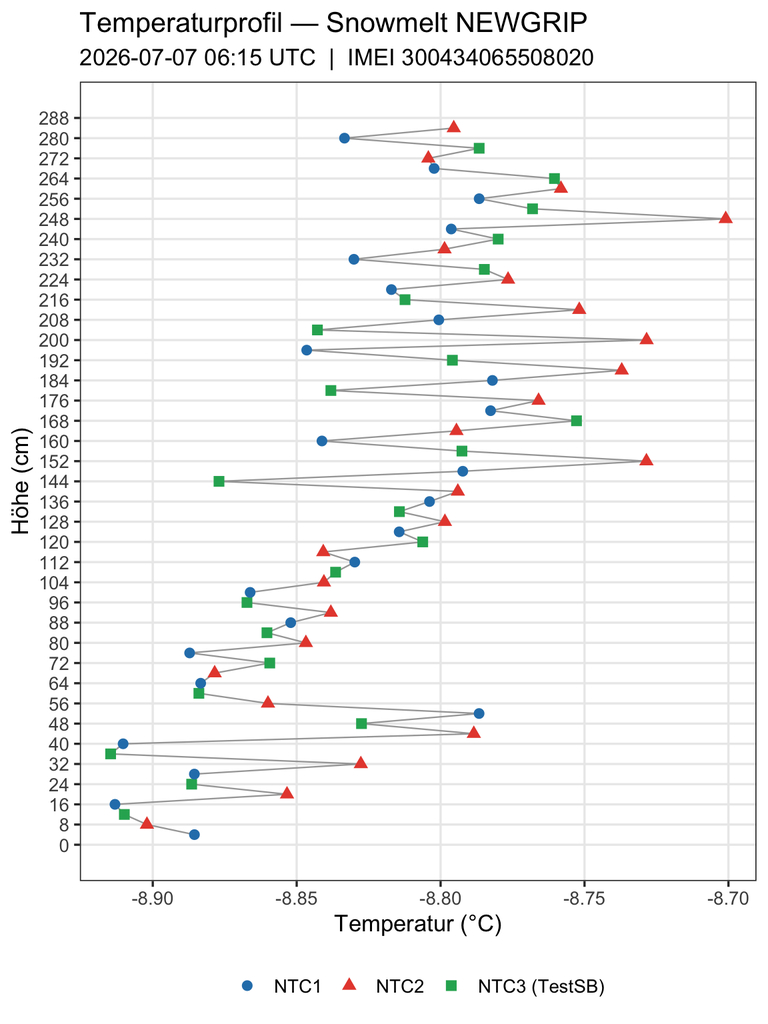

```r
# NTC rank within node: NTC1=1, NTC2=2, TestSB=3; height = (node-1)*3*s + rank*s
s <- cfg$spacing_cm
long <- nodes |>
  select(node, ends_with("_C")) |>
  pivot_longer(ends_with("_C"), names_to = "sensor", values_to = "temp_C") |>
  filter(!is.na(temp_C)) |>          # drop defective sensors (sentinel → NA, e.g. topmost NTC3)
  mutate(
    sensor   = recode(sensor, ntc1_C = "NTC1", ntc2_C = "NTC2", testSB_C = "NTC3 (TestSB)"),
    ntc_rank = case_when(sensor == "NTC1" ~ 1L, sensor == "NTC2" ~ 2L, TRUE ~ 3L),
    hoehe_cm = (node - 1L) * 3L * s + ntc_rank * s
  )

max_h <- n_nodes * 3L * s
ggplot(long, aes(x = temp_C, y = hoehe_cm)) +
  geom_path(data = arrange(long, hoehe_cm), colour = "grey65", linewidth = 0.4) +
  geom_point(aes(colour = sensor, shape = sensor), size = 2.5) +
  scale_y_continuous(
    name   = "Höhe (cm)",
    limits = c(0, max_h),
    breaks = seq(0, max_h, by = max(s, 8L))
  ) +
  scale_x_continuous(name = "Temperatur (°C)") +
  scale_colour_manual(values = c(NTC1 = "#2980b9", NTC2 = "#e74c3c",
                                 "NTC3 (TestSB)" = "#27ae60")) +
  labs(
    title    = sprintf("Temperaturprofil — %s", cfg$label),
    subtitle = sprintf("%s UTC  |  IMEI %s", format(time_utc, "%Y-%m-%d %H:%M"), imei),
    colour   = NULL, shape = NULL
  ) +
  theme_bw(base_size = 13) +
  theme(legend.position = "bottom", panel.grid.minor = element_blank())
```

```r
long_ntc <- nodes |>
  select(node, ends_with("_C")) |>
  pivot_longer(ends_with("_C"), names_to = "sensor", values_to = "temp_C") |>
  filter(!is.na(temp_C)) |>          # drop defective sensors
  mutate(sensor = recode(sensor, ntc1_C = "NTC1", ntc2_C = "NTC2"))

p1 <- ggplot(long_ntc, aes(x = node, y = temp_C, colour = sensor)) +
  geom_line(linewidth = 0.7, alpha = 0.6) +
  geom_point(size = 2) +
  scale_colour_manual(values = c(NTC1 = "#2980b9", NTC2 = "#e74c3c")) +
  labs(title = sprintf("Temperatures — %s", cfg$label),
       subtitle = sprintf("%s UTC  |  IMEI %s",
                          format(time_utc, "%Y-%m-%d %H:%M"), imei),
       x = "Node", y = "Temperature (°C)", colour = NULL) +
  theme_bw(base_size = 13) +
  theme(legend.position = "bottom")

p2 <- ggplot(nodes, aes(x = node, y = gnd)) +
  geom_col(fill = "#7f8c8d", width = 0.6) +
  labs(x = "Node", y = "GND (counts)") +
  theme_bw(base_size = 13)

if ("pressure_hPa" %in% names(nodes)) {
  p3 <- ggplot(nodes, aes(x = node, y = pressure_hPa)) +
    geom_line(colour = "#8e44ad", linewidth = 0.7) +
    geom_point(colour = "#8e44ad", size = 2) +
    labs(x = "Node", y = "Druck (hPa)") +
    theme_bw(base_size = 13)
  p1 / p2 / p3 + plot_layout(heights = c(3, 1, 1))
} else {
  p1 / p2 + plot_layout(heights = c(3, 1))
}
```

## Zeitlicher Verlauf

Only shown when more than one `.bin` file is loaded (a time series). Every message contributes; the single-message sections above show the newest one.

```r
multi <- use_bin && exists("all_bin") && n_msg > 1L
```

```r
# Long table across all messages: one row per (time, node, sensor), carrying
# both the calibrated temperature and the raw counts (pre-calibration). The
# `sensor` key keeps the *_C name so the plots/diagnostics below are unchanged.
series_wide <- bind_rows(lapply(all_bin, function(b)
  bin_to_nodes(b) |> mutate(time = unix2utc(b$time_unix))))

temp_l <- series_wide |> select(node, time, ends_with("_C")) |>
  pivot_longer(ends_with("_C"), names_to = "sensor", values_to = "temp_C")
cnt_l  <- series_wide |> select(node, time, ends_with("_counts")) |>
  pivot_longer(ends_with("_counts"), names_to = "sensor", values_to = "counts") |>
  mutate(sensor = sub("_counts$", "_C", sensor))

series_long <- left_join(temp_l, cnt_l, by = c("node", "time", "sensor")) |>
  filter(!is.na(temp_C))
```

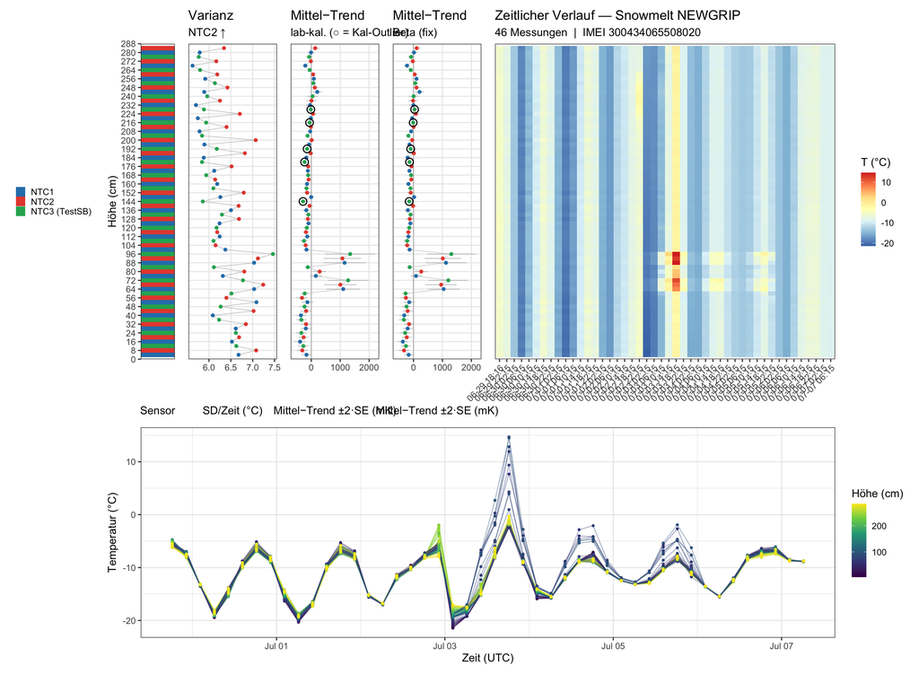

```r
# Two stacked panels over the same time series:
#  (top)    Hovmöller heatmap — Höhe (same axis as the profile plot) × time,
#           fill = temperature. Each measurement is one evenly-spaced column.
#  (bottom) Line plot — temperature vs real time, one line per sensor height,
#           coloured by Höhe; reads the diurnal cooling directly.
s   <- cfg$spacing_cm
ts  <- series_long |>
  mutate(
    sensor    = recode(sensor, ntc1_C = "NTC1", ntc2_C = "NTC2", testSB_C = "NTC3 (TestSB)"),
    ntc_rank  = case_when(sensor == "NTC1" ~ 1L, sensor == "NTC2" ~ 2L, TRUE ~ 3L),
    hoehe_cm  = (node - 1L) * 3L * s + ntc_rank * s,
    height_id = paste(node, sensor)
  )
tlevels <- format(sort(unique(ts$time)), "%m-%d %H:%M")
ts  <- ts |> mutate(tlab = factor(format(time, "%m-%d %H:%M"), levels = tlevels))
max_h <- n_nodes * 3L * s

# Companion strip (left of the heatmap, same y-axis): sensor type at each height.
# Lets you read whether a temperature stripe sits on the NTC2 rows (channel gain)
# or the NTC3 rows (calibration outliers). Full node×rank grid so a defective
# sensor still gets a coloured row.
sensor_cols <- c(NTC1 = "#2980b9", NTC2 = "#e74c3c", "NTC3 (TestSB)" = "#27ae60")
strip_df <- expand.grid(node = seq_len(n_nodes), ntc_rank = 1:3) |>
  mutate(sensor   = factor(c("NTC1", "NTC2", "NTC3 (TestSB)")[ntc_rank],
                           levels = names(sensor_cols)),
         hoehe_cm = (node - 1L) * 3L * s + ntc_rank * s)

p_sensor <- ggplot(strip_df, aes(x = 1, y = hoehe_cm, fill = sensor)) +
  geom_tile() +
  scale_fill_manual(values = sensor_cols, name = NULL) +
  scale_y_continuous(name = "Höhe (cm)", limits = c(0, max_h),
                     breaks = seq(0, max_h, by = max(s, 8L)), expand = c(0, 0)) +
  scale_x_continuous(name = "Sensor", breaks = NULL, expand = c(0, 0)) +
  labs(title = " ", subtitle = " ") +
  theme_bw(base_size = 13) +
  theme(panel.grid = element_blank(), legend.position = "left",
        legend.key.size = unit(0.8, "lines"))

# Two companion curves on the same height axis:
#  (SD)   robust SD over time per sensor height — the NTC2 gain shows as a
#         sawtooth peak on every middle (red) sensor of a node triplet (within a
#         triplet the height trend is ~flat, so NTC2's larger swing pops out).
#  (mean) time-MEDIAN residual from the smooth vertical profile (loess per
#         message) = the fixed per-sensor offset; NTC3 calibration outliers show
#         as persistently cold (negative) points, while the NTC2 gain (∝ T−T0)
#         averages out. Both use robust stats (MAD/median) → the handling-
#         contaminated last message does not dominate.
sensor_by_h <- strip_df |> select(hoehe_cm, sensor)

var_df <- ts |> group_by(hoehe_cm) |>
  summarise(sd_t = 1.4826 * mad(temp_C, na.rm = TRUE), .groups = "drop") |>
  left_join(sensor_by_h, by = "hoehe_cm") |> arrange(hoehe_cm)

# Mittel−Trend = per-height time-median minus a single LINEAR height trend, once
# with the lab calibration and once with the fixed Beta curve (from counts). The
# atmosphere carries no persistent structure beyond the ~linear trend (checked:
# higher-order trends don't shrink the residual, which is white-noise jagged), so
# the jagged residual is a FIXED per-sensor artifact. lab ≈ Beta ⇒ it is mounting/
# geometry (common to both calibrations), NOT calibration error.
ts <- ts |> mutate(temp_beta = NTC_beta(counts))
# Per message: linear height trend → residual per sensor. Offset = mean over
# time; SE = sd/√N is the expected sampling scatter of that mean. Points inside
# ±2·SE are consistent with noise (only ~16/71 clear it at N≈20 → curve is still
# largely under-averaged; longer/colder data needed).
lin_offset <- function(col) {
  d <- ts |> select(time, hoehe_cm, y = all_of(col)) |> filter(is.finite(y)) |>
    group_by(time) |> mutate(r = 1000 * (y - fitted(lm(y ~ hoehe_cm)))) |> ungroup()
  d |> group_by(hoehe_cm) |>
    summarise(off_mK = mean(r), se_mK = sd(r) / sqrt(n()), .groups = "drop") |>
    left_join(sensor_by_h, by = "hoehe_cm")
}
off_lab  <- lin_offset("temp_C")
off_beta <- lin_offset("temp_beta")
xr_off   <- range(c(off_lab$off_mK  + 2 * off_lab$se_mK,  off_lab$off_mK  - 2 * off_lab$se_mK,
                    off_beta$off_mK + 2 * off_beta$se_mK, off_beta$off_mK - 2 * off_beta$se_mK),
                  na.rm = TRUE)

ybreaks <- seq(0, max_h, by = max(s, 8L))
p_var <- ggplot(var_df, aes(sd_t, hoehe_cm)) +
  geom_path(colour = "grey75", linewidth = 0.3) +
  geom_point(aes(colour = sensor), size = 1.5) +
  scale_colour_manual(values = sensor_cols, guide = "none") +
  scale_y_continuous(name = NULL, limits = c(0, max_h), breaks = ybreaks, expand = c(0, 0)) +
  scale_x_continuous(name = "SD/Zeit (°C)") +
  labs(title = "Varianz", subtitle = "NTC2 ↑") +
  theme_bw(base_size = 13) +
  theme(axis.text.y = element_blank(), axis.ticks.y = element_blank(),
        panel.grid.minor = element_blank())

# NTC3 calibration outliers from the coefficient/ReTest check (nodes 71/77/80/
# 50/51/26), at their NTC3-row heights — overlaid as black rings so we can see
# whether they line up with the field offset curve.
cal_outlier_h <- c(144, 180, 192, 216, 228, 288)

mk_mean <- function(d, ttl, sub) {
  out <- d |> filter(hoehe_cm %in% cal_outlier_h)
  ggplot(d, aes(off_mK, hoehe_cm)) +
    geom_vline(xintercept = 0, colour = "grey60", linewidth = 0.3) +
    geom_errorbarh(aes(xmin = off_mK - 2 * se_mK, xmax = off_mK + 2 * se_mK),
                   height = 0, colour = "grey70", linewidth = 0.3) +
    geom_path(colour = "grey80", linewidth = 0.3) +
    geom_point(aes(colour = sensor), size = 1.5) +
    geom_point(data = out, shape = 21, size = 3.6, stroke = 0.9,
               colour = "black", fill = NA) +
    scale_colour_manual(values = sensor_cols, guide = "none") +
    scale_y_continuous(name = NULL, limits = c(0, max_h), breaks = ybreaks, expand = c(0, 0)) +
    scale_x_continuous(name = "Mittel−Trend ±2·SE (mK)", limits = xr_off) +
    labs(title = ttl, subtitle = sub) +
    theme_bw(base_size = 13) +
    theme(axis.text.y = element_blank(), axis.ticks.y = element_blank(),
          panel.grid.minor = element_blank())
}
p_mean_lab  <- mk_mean(off_lab,  "Mittel−Trend", "lab-kal. (○ = Kal-Outlier)")
p_mean_beta <- mk_mean(off_beta, "Mittel−Trend", "Beta (fix)")

p_heat <- ggplot(ts, aes(x = tlab, y = hoehe_cm, fill = temp_C)) +
  geom_tile() +
  scale_fill_distiller(palette = "RdYlBu", direction = -1, name = "T (°C)") +
  scale_y_continuous(name = NULL, limits = c(0, max_h),
                     breaks = seq(0, max_h, by = max(s, 8L)), expand = c(0, 0)) +
  labs(title    = sprintf("Zeitlicher Verlauf — %s", cfg$label),
       subtitle = sprintf("%d Messungen  |  IMEI %s", n_msg, imei),
       x = NULL) +
  theme_bw(base_size = 13) +
  theme(axis.text.x = element_text(angle = 45, hjust = 1),
        axis.text.y = element_blank(), axis.ticks.y = element_blank(),
        panel.grid  = element_blank())

p_line <- ggplot(ts, aes(x = time, y = temp_C,
                         group = height_id, colour = hoehe_cm)) +
  geom_line(alpha = 0.5, linewidth = 0.4) +
  geom_point(size = 1) +
  scale_colour_viridis_c(name = "Höhe (cm)") +
  labs(x = "Zeit (UTC)", y = "Temperatur (°C)") +
  theme_bw(base_size = 13)

(p_sensor + p_var + p_mean_lab + p_mean_beta + p_heat +
   plot_layout(widths = c(0.5, 1.3, 1.3, 1.3, 5))) / p_line +
  plot_layout(heights = c(3, 2))
```

```r
ts <- series_long |>
  mutate(sensor = recode(sensor, ntc1_C = "NTC1", ntc2_C = "NTC2"))

ggplot(ts, aes(x = time, y = temp_C, colour = node, group = interaction(node, sensor))) +
  geom_line(alpha = 0.5, linewidth = 0.4) +
  geom_point(size = 1) +
  scale_colour_viridis_c(name = "Node") +
  labs(title    = sprintf("Zeitlicher Verlauf — %s", cfg$label),
       subtitle = sprintf("%d Messungen  |  IMEI %s", n_msg, imei),
       x = "Zeit (UTC)", y = "Temperatur (°C)") +
  theme_bw(base_size = 13)
```

## NTC2-Diagnose

NTC1 / NTC2 / NTC3 sind je Node quasi am selben Ort, sollten also denselben Tagesgang sehen. Hier wird geprüft, ob **NTC2 systematisch einen stärkeren Tagesgang** hat als die beiden anderen (beobachtet in frühen Felddaten). Zwei Maße, jeweils paarweise je Node ausgewertet:

- **Amplitude** = max − min der Temperatur über die geladenen Messungen.
- **Sensitivität** = Regressions-Slope des Sensors gegen das gemeinsame Signal (Mittel aller Sensoren pro Zeit); > 1 ⇒ reagiert stärker als der Durchschnitt.

Läuft nur für Snowmelt-Köpfe mit NTC1/NTC2/NTC3 und mehreren Messungen.

```r
safe_amp <- function(x) { x <- x[is.finite(x)]; if (length(x) < 2L) NA_real_ else diff(range(x)) }

diag_long <- series_long |>
  mutate(sensor = recode(sensor, ntc1_C = "NTC1", ntc2_C = "NTC2", testSB_C = "NTC3"))

# Common diurnal forcing = mean over all sensors at each time.
common_df <- diag_long |> group_by(time) |>
  summarise(common = mean(temp_C, na.rm = TRUE), .groups = "drop")

# Per node × sensor: amplitude and sensitivity (slope vs common forcing).
per_node <- diag_long |>
  left_join(common_df, by = "time") |>
  group_by(node, sensor) |>
  summarise(
    amp   = safe_amp(temp_C),
    slope = if (sum(is.finite(temp_C)) >= 2L)
              cov(temp_C, common, use = "complete.obs") / var(common) else NA_real_,
    .groups = "drop"
  )

# Wide per node to compare NTC2 against the mean of NTC1 & NTC3 (paired).
amp_w <- per_node |> select(node, sensor, amp) |>
  pivot_wider(names_from = sensor, values_from = amp) |>
  mutate(ref = (NTC1 + NTC3) / 2, d = NTC2 - ref)

summary_tab <- per_node |> group_by(sensor) |>
  summarise(`Amplitude ⌀ (°C)` = mean(amp,   na.rm = TRUE),
            `Slope ⌀`          = mean(slope, na.rm = TRUE),
            `n Nodes`          = sum(!is.na(amp)), .groups = "drop")

n_ok       <- sum(!is.na(amp_w$d))
n_strong   <- sum(amp_w$NTC2 > amp_w$NTC1 & amp_w$NTC2 > amp_w$NTC3, na.rm = TRUE)
amp_diff   <- mean(amp_w$d, na.rm = TRUE)
pval       <- tryCatch(t.test(amp_w$NTC2, amp_w$ref, paired = TRUE)$p.value,
                       error = function(e) NA_real_)
ntc2_amp   <- summary_tab$`Amplitude ⌀ (°C)`[summary_tab$sensor == "NTC2"]
others_amp <- max(summary_tab$`Amplitude ⌀ (°C)`[summary_tab$sensor != "NTC2"])
ntc2_stronger <- isTRUE(ntc2_amp > others_amp) && isTRUE(!is.na(pval) && pval < 0.05)
```

```r
knitr::kable(summary_tab, digits = c(0, 2, 3, 0),
             caption = sprintf("Pro-Sensor-Mittel über %d Messungen", n_msg))
```

Pro-Sensor-Mittel über 46 Messungen

| sensor | Amplitude ⌀ (°C) | Slope ⌀ | n Nodes |
| --- | --- | --- | --- |
| NTC1 | 19.23 | 0.990 | 24 |
| NTC2 | 19.58 | 1.020 | 24 |
| NTC3 | 19.19 | 0.989 | 23 |

```r
col <- if (ntc2_stronger) "#e67e22" else "#2ecc71"
tag <- if (ntc2_stronger) "AUFFÄLLIG" else "unauffällig"
cat(sprintf(
  '<span style="color:%s">**%s**</span> — NTC2 vs. Mittel(NTC1, NTC3), paarweise je Node:\n\n',
  col, tag))
```

**AUFFÄLLIG** — NTC2 vs. Mittel(NTC1, NTC3), paarweise je Node:

```r
cat(sprintf("- Amplitude im Mittel **%+.2f °C** stärker als NTC1/NTC3.\n", amp_diff))
```

- Amplitude im Mittel **+0.37 °C** stärker als NTC1/NTC3.

```r
cat(sprintf("- NTC2 am stärksten in **%d / %d** Nodes.\n", n_strong, n_ok))
```

- NTC2 am stärksten in **16 / 23** Nodes.

```r
cat(sprintf("- Paired t-Test (Amplitude): **p = %s**.\n",
            if (is.na(pval)) "n/a" else formatC(pval, format = "g", digits = 2)))
```

- Paired t-Test (Amplitude): **p = 0.011**.

```r
cat(sprintf("\n%s\n",
  if (ntc2_stronger)
    "→ NTC2 zeigt einen systematisch stärkeren Tagesgang (wahrscheinlich Kanal-/Sensor-Effekt). Mit mehr vollen Tageszyklen bestätigen."
  else
    "→ Kein systematischer Mehr-Tagesgang von NTC2 in diesen Daten."))
```

→ NTC2 zeigt einen systematisch stärkeren Tagesgang (wahrscheinlich Kanal-/Sensor-Effekt). Mit mehr vollen Tageszyklen bestätigen.

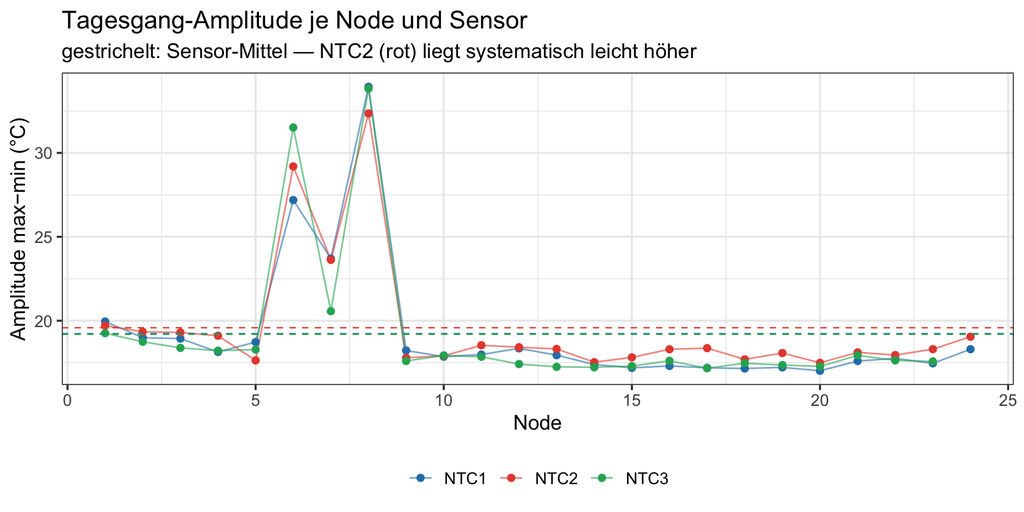

```r
ggplot(per_node, aes(x = node, y = amp, colour = sensor)) +
  geom_line(alpha = 0.6, linewidth = 0.5) +
  geom_point(size = 1.8) +
  geom_hline(data = summary_tab,
             aes(yintercept = `Amplitude ⌀ (°C)`, colour = sensor),
             linetype = "dashed", linewidth = 0.4, show.legend = FALSE) +
  scale_colour_manual(values = c(NTC1 = "#2980b9", NTC2 = "#e74c3c", NTC3 = "#27ae60")) +
  labs(title = "Tagesgang-Amplitude je Node und Sensor",
       subtitle = "gestrichelt: Sensor-Mittel — NTC2 (rot) liegt systematisch leicht höher",
       x = "Node", y = "Amplitude max−min (°C)", colour = NULL) +
  theme_bw(base_size = 13) +
  theme(legend.position = "bottom")
```

## Save result

```r
# Newest message → per-node table (as before).
slug    <- if (use_bin) tools::file_path_sans_ext(basename(primary_file)) else paste0("imei", imei)
outfile <- sprintf("data/decoded_%s_%s.csv", slug, format(time_utc, "%Y%m%d_%H%M%S"))
write.csv(nodes, outfile, row.names = FALSE)
cat("Saved:", outfile, "\n")
```

```
Saved: data/decoded_300434065508020-48_20260707_061557.csv
```

```r
# Whole time series → one long CSV (time, node, sensor, temp_C).
if (exists("multi") && multi) {
  ts_file <- sprintf("data/series_imei%s_%s.csv", imei, format(time_utc, "%Y%m%d_%H%M%S"))
  write.csv(series_long, ts_file, row.names = FALSE)
  cat("Saved series:", ts_file, "\n")
}
```

```
Saved series: data/series_imei300434065508020_20260707_061557.csv
```